# Section 5: Medicare Advantage Quality and Regression Discontinuity

Ian McCarthy | Emory University

Econ 470 & HLTH 470

# Table of contents

1. Medicare Advantage and Quality
2. Regression Discontinuity in Theory
3. Regression Discontinuity in Practice
4. Fuzzy Regression Discontinuity
5. Medicare Advantage Data
6. Quality and Insurance Choice

class: inverse, center, middle name: ma_quality

# Background on Medicare Advantage and Quality

# Medicare Advantage History

- Existed since 1980s, formalized in the 1990s, expanded in 2000s
- Medicare+Choice as part of Balanced Budget Act in 1997
- Largest expansion: Medicare Modernization Act in 2003 (also brought Medicare Part D)

# Medicare Advantage in Real Life

Let’s take a look at the Medicare Advantage plan options…

[output not shown]

**key point:** ratings from several domains are averaged and then rounded

class: inverse, center, middle name: rd_theory

# Regression Discontinuity in Theory

# Intuition

Highly relevant in “rule-based” world… - School eligibility based on age cutoffs - Program participation based on discrete income thresholds - Performance scores rounded to nearest integer

# Sharp RD

$$W_{i} = 1(x_{i}>c) = \begin{cases}
1 & \text{if} & x_{i}>c \\
0 & \text{if} & x_{i}<c
\end{cases}$$

- $x$ is “forcing variable” - $c$ is the threshold value or cutoff point

# Sharp RD Linear Predictions

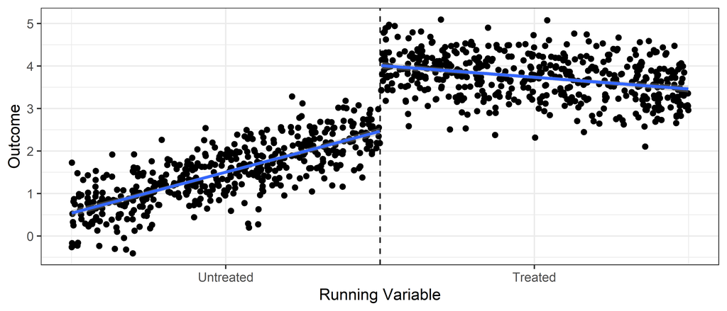

# Different averages

- Mean difference around threshold of 0.2, 3.97 - 2.25 = 1.72
- Mean overall difference, 3.74 - 1.49 = 2.25

# Animations!

.center[

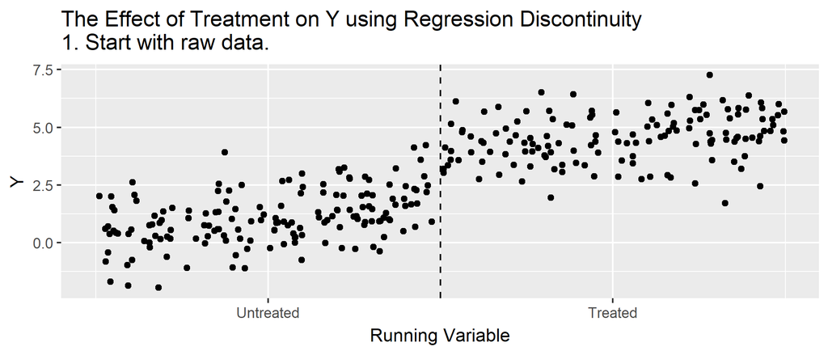

]

class: inverse, center, middle name: rd_practice